# §1.3b — Timescales In the Universe: Orbits and Time

Unit 1: Intro to the Cosmos · Astronomy

[figure not shown]

Every picture of the solar system you have seen looks something like this one: the planets crowded together, close enough to touch. **This is a BAD picture, because objects are not to scale.** With the sizes right you could not see the small planets at all. With the distances right the page would be more than a kilometer wide.

Today: how fast the planets move, and how long things take, from 8 minutes to 13.8 billion years.

Solar System Montage, artist's concept. NASA/JPL

## 1 · The numbers at a glance

🌍

you have moved 30 km since you started reading this line

☀️

4.56 Gyr

Age of the solar system

the Sun has been around the Milky Way about 19 times, once every 240 Myr

⏳

13.8 Gyr

Age of the Universe

the longest time there is

## 2 · Orbits and time

Click a tile.

[figure not shown]

[figure not shown]

1

Orbital Velocity

the speed any planet orbits at

[figure not shown]

2

Timescales

eight minutes to 13.8 billion years

← scroll the tiles →

### Orbital Velocity

**$V_{\rm orb}$: the speed any planet orbits at.** It is the same $v = \dfrac{d}{t}$. The distance is once around the orbit, a circle of circumference $2\pi r$. The time is one year for that planet.

[interactive chart not shown]

Ex. 3 · Calculate the Earth's orbital velocity

**A.** What is the distance (in meters) Earth travels in 1 yr? Use $r = 1.5\times10^{11}$ m.

**Reveal**

$d = 2\pi r = 2\pi\left(1.5\times10^{11}\ \text{m}\right) = \boxed{9.42\times10^{11}\ \text{m}}$

**B.** How many seconds in a year?

**Reveal**

$t = 365\times24\times60\times60 = \boxed{3.15\times10^{7}\ \text{s}}$

**C.** What is the orbital velocity of Earth in m/s?

**Reveal**

$v_{\rm orb} = \dfrac{d}{t} = \dfrac{9.42\times10^{11}\ \text{m}}{3.15\times10^{7}\ \text{s}} = \boxed{2.99\times10^{4}\ \text{m/s}}$

**D.** What is the orbital velocity of Earth in km/s?

**Reveal**

$v_{\rm orb} = 2.99\times10^{4}\ \text{m/s}\times\dfrac{1\ \text{km}}{1000\ \text{m}} = \boxed{30\ \text{km/s}}$. Memorize this one.

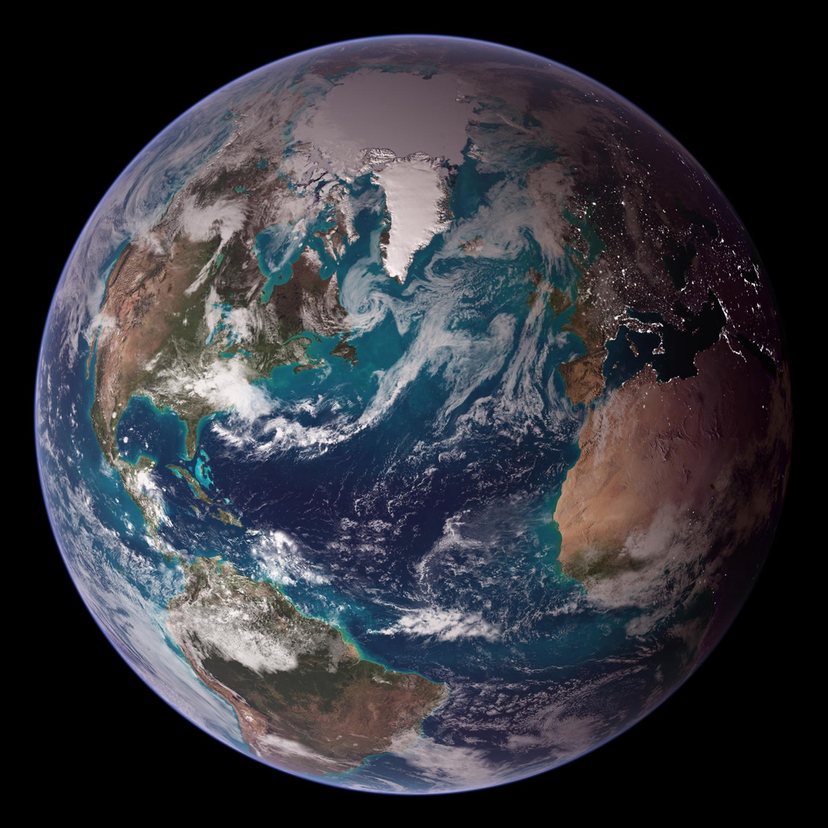

**Earth:** 30 km/s, and you feel nothing. NASA/GSFC (Blue Marble)

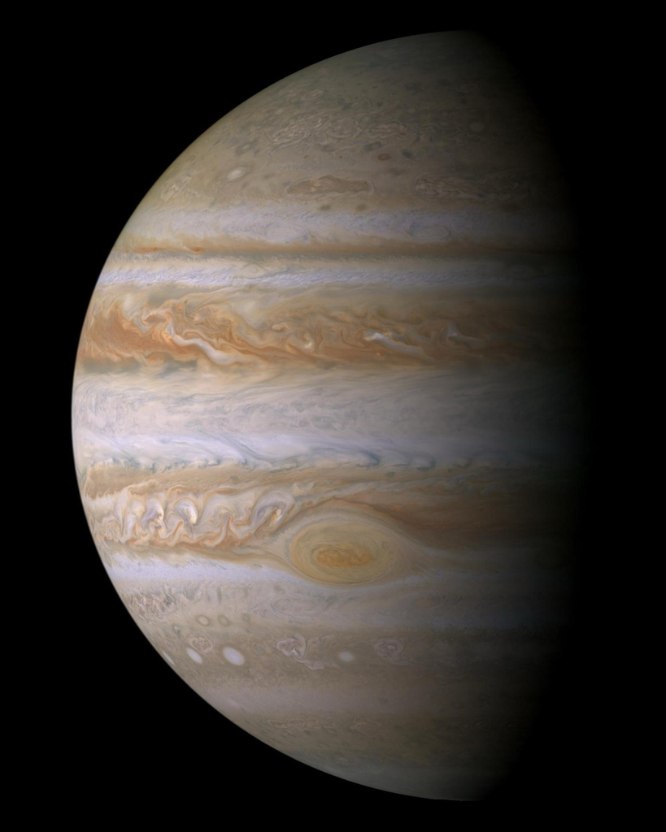

**Jupiter:** 5.20 AU out, with a year 11.86 of ours long. Faster or slower than Earth? NASA/JPL/Space Science Institute

Your turn: another planet's orbital velocity

| distance once around, $2\pi r$ | km |
| --- | --- |
| seconds in its year | s |
| $v_{\rm orb} = d/t$ | km/s |

[interactive chart not shown]

Use 1 AU $= 1.5\times10^{8}$ km and one Earth year $= 3.15\times10^{7}$ s. Each planet you get right joins the chart.

### Timescales

**Sort these times from shortest to longest by estimating their lengths.** Drag a row (on a phone, drag it by the ⋮⋮ handle), or use the arrows. You do not need exact values. You need the order of magnitude, the power of ten, which you met with scientific notation.

Shortest at the top, longest at the bottom

[interactive chart not shown]

**Sources and further reading**

Want to dig deeper? Each title links straight to the original.

**Orbital velocity**

- [Planetary orbits](https://science.nasa.gov/learn/basics-of-space-flight/chapter5-1/) (NASA/JPL Basics of Space Flight): why closer planets orbit faster.
- [Planetary Fact Sheet](https://nssdc.gsfc.nasa.gov/planetary/factsheet/) (NASA): distances, sizes, years and orbital speeds for every planet in one table.

**Timescales: the oldest light**

- [Planck's map of the oldest light](https://www.esa.int/Science_Exploration/Space_Science/Planck/Planck_reveals_an_almost_perfect_Universe) (ESA): the cosmic microwave background and what it tells us about the universe.
- [WMAP](https://science.nasa.gov/mission/wmap/wmap-overview/) (NASA): the earlier spacecraft that first pinned down the age of the universe.
- [The age of the universe from Planck](https://doi.org/10.1051/0004-6361/201833910): the paper that measures the age as 13.8 billion years. Free to read (also on [arXiv](https://arxiv.org/abs/1807.06209)). Planck Collaboration 2020, Astronomy & Astrophysics

The page's numbers come from the class notes; to check a planet's size, distance or year, use NASA's Planetary Fact Sheet. All pictures are from the NASA Image and Video Library.

**Image credits**

All pictures are from the NASA Image and Video Library. Solar System Montage (PIA10969), NASA/JPL. Handle-shaped Prominence (PIA03149), SOHO (ESA & NASA). Pale Blue Dot Revisited (PIA23645), NASA/JPL-Caltech. Blue Marble 2007 West, NASA/GSFC. Portrait of Pluto and Charon (PIA19717), NASA/Johns Hopkins University Applied Physics Laboratory/Southwest Research Institute. Cassini Jupiter Portrait (PIA04866), NASA/JPL/Space Science Institute. Alpha Centauri A and B, ESA/Hubble and NASA. Our Milky Way Gets a Makeover, artist's concept (PIA10748), NASA/JPL-Caltech (R. Hurt). Andromeda Galaxy (PIA04921), NASA/JPL/California Institute of Technology (GALEX). Hubble eXtreme Deep Field, NASA, ESA, and the HUDF09/XDF teams. Best Map Ever of the Universe (PIA16873), ESA and the Planck Collaboration.